# IMDB Ratings

IMDB provides breakdown of votes and ratings per gender and age group (for example see “http://www.imdb.com/title/tt2713180/ratings”). This data was scraped for all the movies that have more than 10,000 votes (all 5,374 of them!).

Loading packages and data.

What is the ratio of male/female voters?

```
## Average number of male voters for a movie:  53708
```

```
## Average number of female voters for a movie:  13136
```

```
## Ratio of male/female voters:  4.088611
```

Do men and women rate movies differently?

```
## Average rating of a movie by male voters:  6.534041
```

```
## Average rating of a movie by female voters:  6.671709
```

So how does age affect the rating?

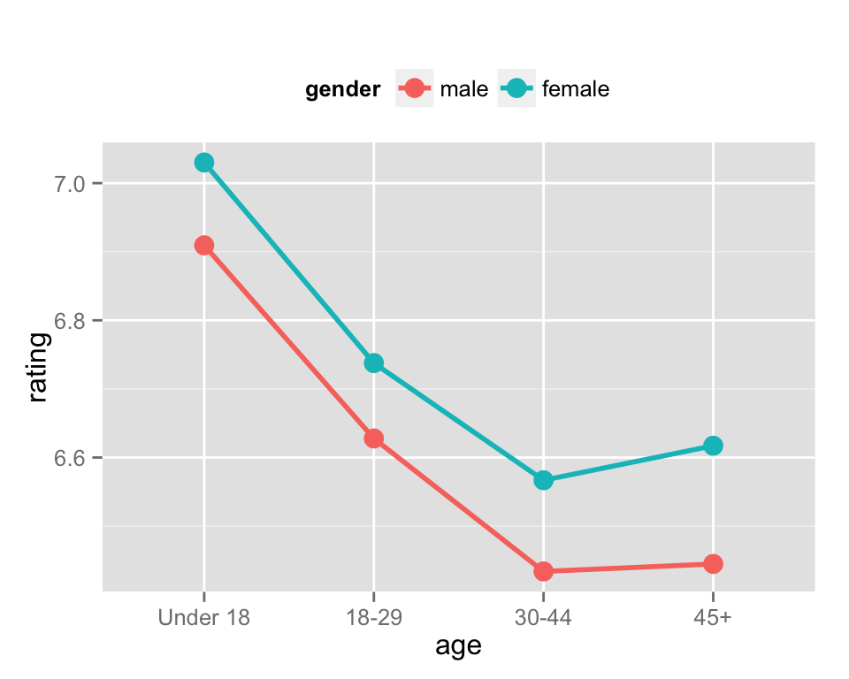

Clearly the younger generation vote more favorably than the adults!

Are newer movies getting better ratings?

```
## geom_smooth: method="auto" and size of largest group is >=1000, so using gam with formula: y ~ s(x, bs = "cs"). Use 'method = x' to change the smoothing method.
```

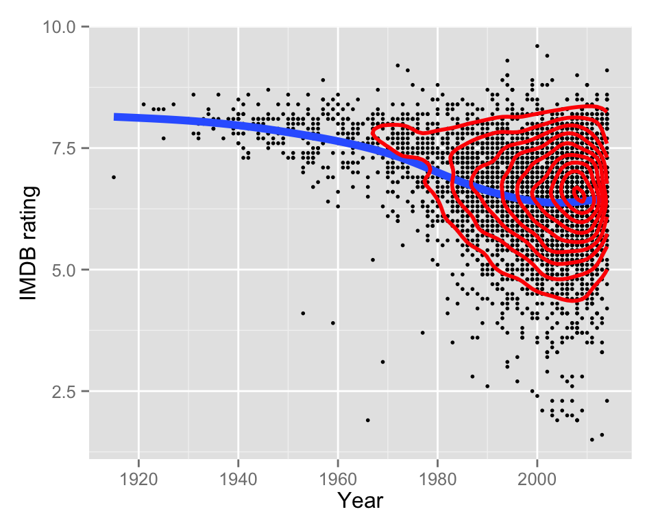

Apparently not! But does this mean old movies were better? Perhaps not. People might just be nostalgic, and hence biased about them.

Which genres are more prevalent among the highly-voted movies?

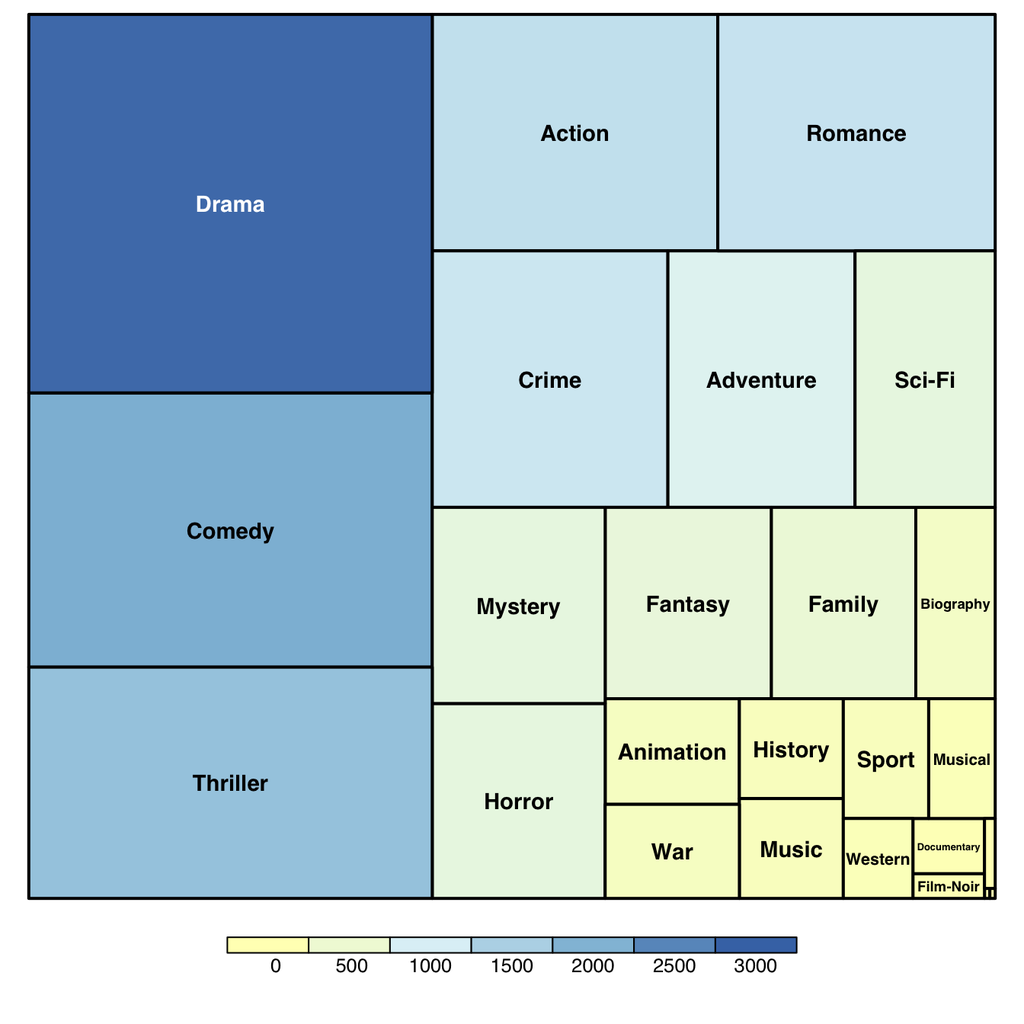

Now let’s focus on the difference between men and women with regards to their tastes in movies. Let’s see which movies are more popular with women:

[output not shown]

and here’s the list for the movies more popular with men:

```
##                  title year male_rating female_rating IMDb_rating
##             Middle Men 2009         6.7           5.1         6.5
##           Free to Play 2014         8.4           6.9         8.5
##              Red River 1948         7.9           6.8         7.8
##  My Darling Clementine 1946         7.8           6.7         7.8
##             The Circus 1928         8.2           7.2         8.1
##               Scarface 1932         7.9           7.0         7.8
##             White Heat 1949         8.2           7.3         8.2
##                   Adam 2009         8.3           7.5         8.3
##          Dumb & Dumber 1994         7.4           6.6         7.3
##                   They 2002         9.5           8.7         9.4
##              Fail-Safe 1964         8.0           7.2         8.0
##    Freddy Got Fingered 2001         4.6           3.8         4.5
##        Ace in the Hole 1951         8.2           7.4         8.2
##                   Life 1999         8.9           8.2         8.8
##       Punch-Drunk Love 2002         7.4           6.7         7.3
##             Stagecoach 1939         8.0           7.3         7.9
##        Out of the Past 1947         8.1           7.4         8.1
##                 Patton 1970         8.1           7.4         8.0
##         The Wild Bunch 1969         8.1           7.4         8.1
##  2001: A Space Odyssey 1968         8.4           7.8         8.3
##                  Borat 2006         7.4           6.8         7.3
##         Eyes Wide Shut 1999         7.4           6.8         7.3
##            First Blood 1982         7.7           7.1         7.7
##         Little Big Man 1970         7.7           7.1         7.7
##     Observe and Report 2009         5.9           5.3         5.8
```

If we are not familiar with these movies, we can just look at the genres that are more popular with each gender. We’ll take the first 100 movies that are more popular with each group, and see what they are. Drama and comedy were removed, as they were both equally popular with men and women.

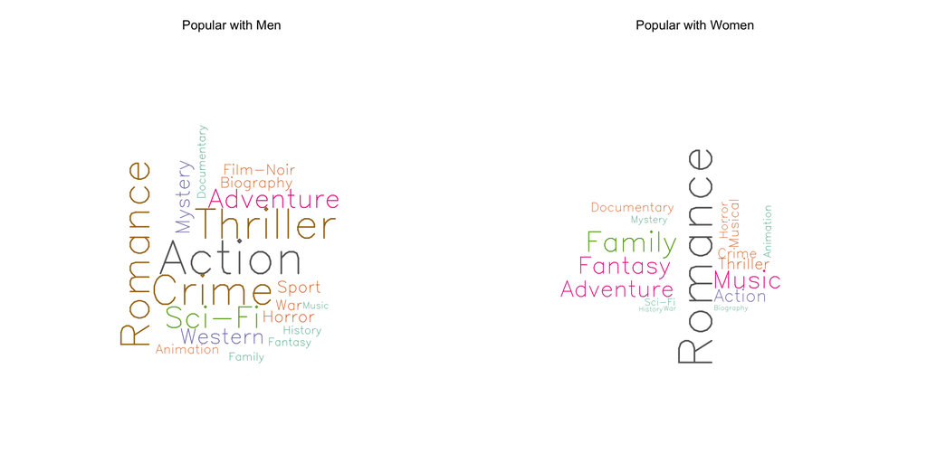

As expected, women enjoy romance and family movies more than men, and men enjoy crime, thriller, and action movies more. Music and fantasy genre are also more popular with women, probably because of Twilight series and Bieber-type movies that are not very popular with men.

Now, let’s take a look at at actors/actresses, and see which ones appear more in the first 250 top-rated movies.

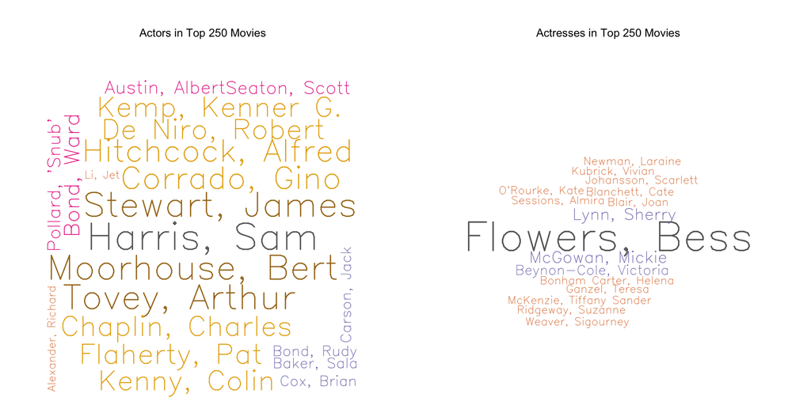

This is not as obvious as the genres graph. I personally expected to see names like Al Pacino, Robert Deniro, and Meryl Strip here, but most of these names are unknown to me. So I looked them up, and realized that they are mostly actors that had uncredited roles in many many movies. So although they appear in many top 250 movies of all times, this does not mean they had central roles!